# Homework 3

1a) Which algorithm makes the fewest mistakes?

NN makes fewer mistakes than NA, 8 compared to 12

1b) Which algorithm is better for the zoo? Explain.

NA is beter for the zoo because birds mistaken for people cause large problems, but people mistaken for birds causes only a slight setback. This makes missed birds far more detrimental, and NA misses fewer birds.

1c) During the pandemic the number of visitors plummets, and it is only the zoo keeper visiting. So instead of 52% of the photos taken at the aviary door being people, it is now only 1%. Make new truth tables for both algorithms.

NN gives a 90.4% chance of correct person identification and 93% correct bird identification. Applying this to the new numbers: 99:1 birds to people, we get a truth table of:

```
NN Person (true Person): 1 (0.90)

NN person (false person): 0 (0.10)

NN bird (True bird): 92 (0.93)

NN bird (false bird): 7 (0.07)
```

NA gives a 79% cance of correct persond identification and 97.9% chance of bird identification. Applying this to the new numbers: 99:1 birds to people, we get a truth table of:

```
NA Person (true Person): 1 (0.79)

NA person (false person): 0 (0.21)

NA bird (True bird): 97 (0.98)

NA bird (false bird): 2 (0.02)
```

2a) What is the pdf of the sum of two identical exponential distributions?

The sum of two identical exponential distributions is a Erlang distribution.

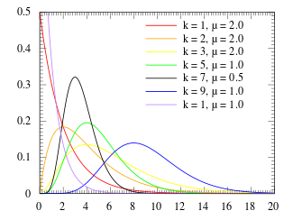

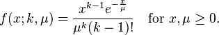

2b) What is the pdf of the ratio of two zero-mean unity variance normal distributions X1/X2 ?

The Ratio of two standard normal distributions results in a Cauchy distribution.

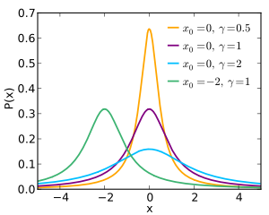

[figure not shown]

2c) So far we have looked at 1D probability distributions, but it is possible to have a multi-dimensional vector distribution. A simple first introduction is the 2D Guassian; it looks like a smeared spot. Mathematically this is given by Xi^+Yj^ where both X and Y are drawn from 1D Gaussian distributions. If I measure the amplitude of this vector, what is its pdf? (Hint, the amplitude is always positive.)

The amplitude of a x-y vector is = sqrt(x^2 + y^2), the probability distributions should will be similiar... A single squared Normal distribution leads to a Chi-Square distribution, In this case we have X and Y so this Chi squared distribution will have 2 degrees of freedom. A Chi square distribution with 2 degrees of freedom leads to an exponential distribution. And finally the square root of an exponential distribution becomes a Rayleigh distribution.

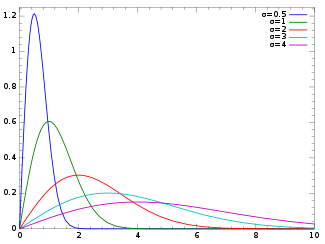